# KNN ALGORITHM

The value of a data point is determined by the data points around itK = 1 If you have one very close friend and spend most of your time with him/her, you will end up sharing similar interests and enjoying same things. That is kNN with k=1K = 5 If you always hang out with a group of 5, each one in the group has an effect on your behavior and you will end up being the average of 5. That is kNN with k=5.kNN classifier determines the class of a data point by majority voting principle. If k is set to 5, the classes of 5 closest points are checked. Prediction is done according to the majority class

```python
import numpy as np
import pandas as pd

import matplotlib.pyplot as plt #data visualization

from sklearn.datasets import make_blobs #synthetic dataset
from sklearn.neighbors import KNeighborsClassifier #kNN classifier
from sklearn.model_selection import train_test_split #train and test sets
```

```python
make_blobs
```

```
<function sklearn.datasets._samples_generator.make_blobs(n_samples=100, n_features=2, centers=None, cluster_std=1.0, center_box=(-10.0, 10.0), shuffle=True, random_state=None)>
```

Scikit-learn provides many useful functions to create synthetic datasets which are very helpful for practicing machine learning algorithms. I will use make_blobs function.

```python
#create synthetic dataset
X, y = make_blobs(n_samples = 100, n_features = 2, centers = 4,
                       cluster_std = 1.5, random_state = 4)
```

```python
X
```

[output not shown]

[output cut: 45 more lines]

[output not shown]

```python
from collections import Counter
```

```python
Counter(y)
```

```
Counter({2: 25, 0: 25, 1: 25, 3: 25})
```

This code creates a dataset with 100 samples divided into 4 classes and the number of features is 2. Number of samples, features and classes can easily be adjusted using related parameters. We can also adjust how much each cluster (or class) is spread. Let’s visualize this synthetic data set:

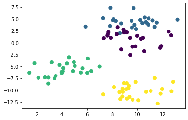

```python
plt.scatter(X[:,0], X[:,1], c=y, marker= 'o', s=50)
plt.show()
```

# TRAIN TEST SPLIT

We can specify how much of the original data is used for train or test sets using train_size or test_size parameters, respectively. Default separation is 75% for train set and 25% for test set.

```python
X_train, X_test, y_train, y_test = train_test_split(X, y, random_state = 0)
```

# CREATE KNN MODEL ( K = 1) ( K=5)

Then we create a kNN classifier object. To show the difference between the importance of k value, I create two classifiers with k values 1 and 5. Then these models are trained using train set. n_neighbors parameter is used to select k value. Default value is 5 so it does not have to be explicitly written.

```python
knn5 = KNeighborsClassifier() #k=5
knn1 = KNeighborsClassifier(n_neighbors=1) #k=1
```

# FIT X_train and y_train in KNN MODEL

```python
knn5.fit(X_train, y_train)
knn1.fit(X_train, y_train)
```

```
KNeighborsClassifier(algorithm='auto', leaf_size=30, metric='minkowski',
                     metric_params=None, n_jobs=None, n_neighbors=1, p=2,
                     weights='uniform')
```

# PREDICT THE TARGET VALUES

Then we predict the target values in the test set and compare with actual values.

```python
y_pred_5 = knn5.predict(X_test)
y_pred_1 = knn1.predict(X_test)
```

# FINDING ACCURACY

```python
from sklearn.metrics import accuracy_score
print("Accuracy of kNN with k=5", accuracy_score(y_test, y_pred_5))
print("Accuracy of kNN with k=1", accuracy_score(y_test, y_pred_1))
```

```
Accuracy of kNN with k=5 0.92
Accuracy of kNN with k=1 0.92
```

# PASS THE TEST DATA TO THE CREATED MODEL

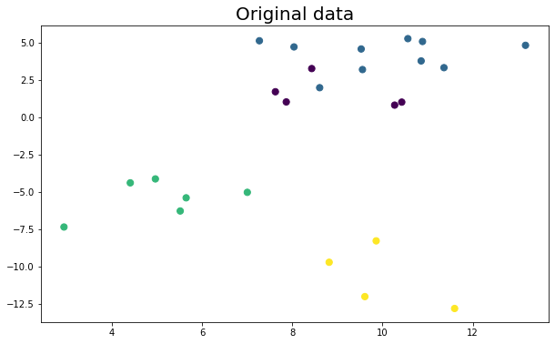

```python
plt.figure(figsize = (10,6))
plt.scatter(X_test[:,0], X_test[:,1], c=y_test, marker= 'o', s=50)
plt.title("Original data", fontsize=20)
plt.show()
```

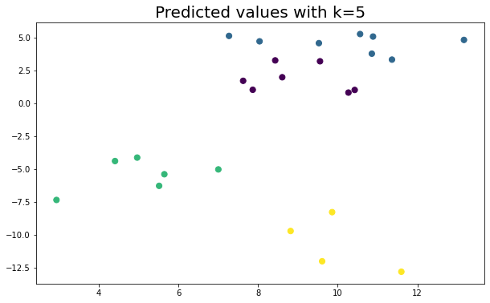

```python
plt.figure(figsize = (10,6))
plt.scatter(X_test[:,0], X_test[:,1], c=y_pred_5, marker= 'o', s=50)
plt.title("Predicted values with k=5", fontsize=20)
plt.show()
```

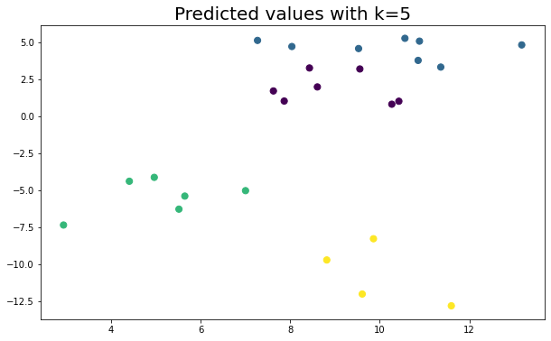

```python
plt.figure(figsize = (10,6))
plt.scatter(X_test[:,0], X_test[:,1], c=y_pred_5, marker= 'o', s=50)
plt.title("Predicted values with k=5", fontsize=20)
plt.show()
```

# CONCLUSION

# ADVANTAGE OF KNN

Simple and easy to interpret Does not make any assumption so it can be implemented in non-linear tasks. Works well on classification with multiple classes Works on both classification and regression tasks

# DISADVANTAGE OF KNN

Becomes very slow as the number of data points increases because the model needs to store all data points. Not memory efficient Sensitive to outliers. Outliers also have a vote!